# Practical: Data Preparation

Laura Rodriguez Navas

February 2020

## Exercise 1: Inspection of data.

The “titanic.csv” file (available on the platform) contains data on the sinking of the Titanic. Copy the file in your working directory. Then, go to R and use the command:

```r
titanic <- read.csv("titanic.csv",header=TRUE, sep=",")
```

Show the names of the columns.

```r
head(titanic, 1)
```

```
##   X Class  Sex   Age Survived Freq
## 1 1   1st Male Child       No    0
```

Observe that the first column (whose name is “X”) is redundant (it denotes the identifier of each in- stance) so it could be removed. To do this, use the subset command as follows (use help if needed):

```r
titanic <- subset(titanic, select=-X)
```

Now try the following commands:

```r
titanic
```

```
##    Class    Sex   Age Survived Freq
## 1    1st   Male Child       No    0
## 2    2nd   Male Child       No    0
## 3    3rd   Male Child       No   35
## 4   Crew   Male Child       No    0
## 5    1st Female Child       No    0
## 6    2nd Female Child       No    0
## 7    3rd Female Child       No   17
## 8   Crew Female Child       No    0
## 9    1st   Male Adult       No  118
## 10   2nd   Male Adult       No  154
## 11   3rd   Male Adult       No  387
## 12  Crew   Male Adult       No  670
## 13   1st Female Adult       No    4
## 14   2nd Female Adult       No   13
```

[output cut: 18 more lines]

```r
head(titanic)
```

```
##   Class    Sex   Age Survived Freq
## 1   1st   Male Child       No    0
## 2   2nd   Male Child       No    0
## 3   3rd   Male Child       No   35
## 4  Crew   Male Child       No    0
## 5   1st Female Child       No    0
## 6   2nd Female Child       No    0
```

```r
summary(titanic)
```

```
##   Class       Sex        Age     Survived      Freq
##  1st :8   Female:16   Adult:16   No :16   Min.   :  0.00
##  2nd :8   Male  :16   Child:16   Yes:16   1st Qu.:  0.75
##  3rd :8                                   Median : 13.50
##  Crew:8                                   Mean   : 68.78
##                                           3rd Qu.: 77.00
##                                           Max.   :670.00
```

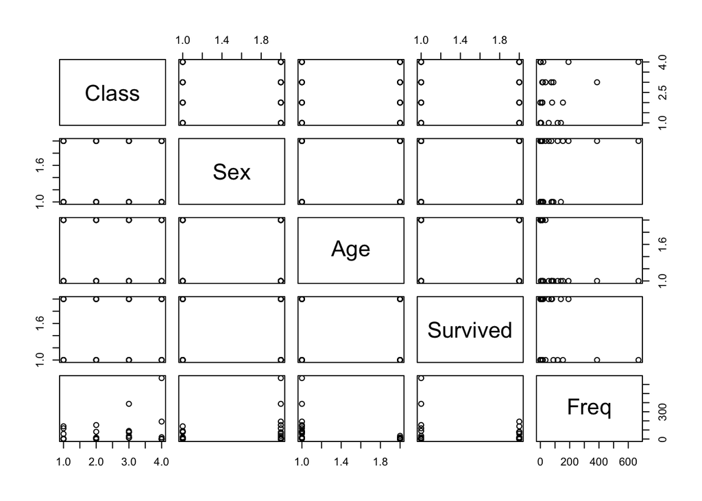

```r
plot(titanic)
```

Which variables are quantitative and which variables are categorical? How can we know it?

The categorical variables are: class, sex, age and survived. Because each variable can be classified into different categories. The variable frequency is quantitative because is a numerical variable.

## Exercise 2: Working with basic graphics.

Download the file “cars.csv” from the platform. This file contains information about the speed and stopping distances of cars.

```r
cars <- read.csv("cars.csv", header=TRUE, sep=",")
cars <- subset(cars, select=-X)
cars
```

```
##    speed dist
## 1      4    2
## 2      4   10
## 3      7    4
## 4      7   22
## 5      8   16
## 6      9   10
## 7     10   18
## 8     10   26
## 9     10   34
## 10    11   17
## 11    11   28
## 12    12   14
## 13    12   20
## 14    12   24
```

[output cut: 36 more lines]

2.1 Make a plot of the distance field in terms of the speed field (use the $ syntax).

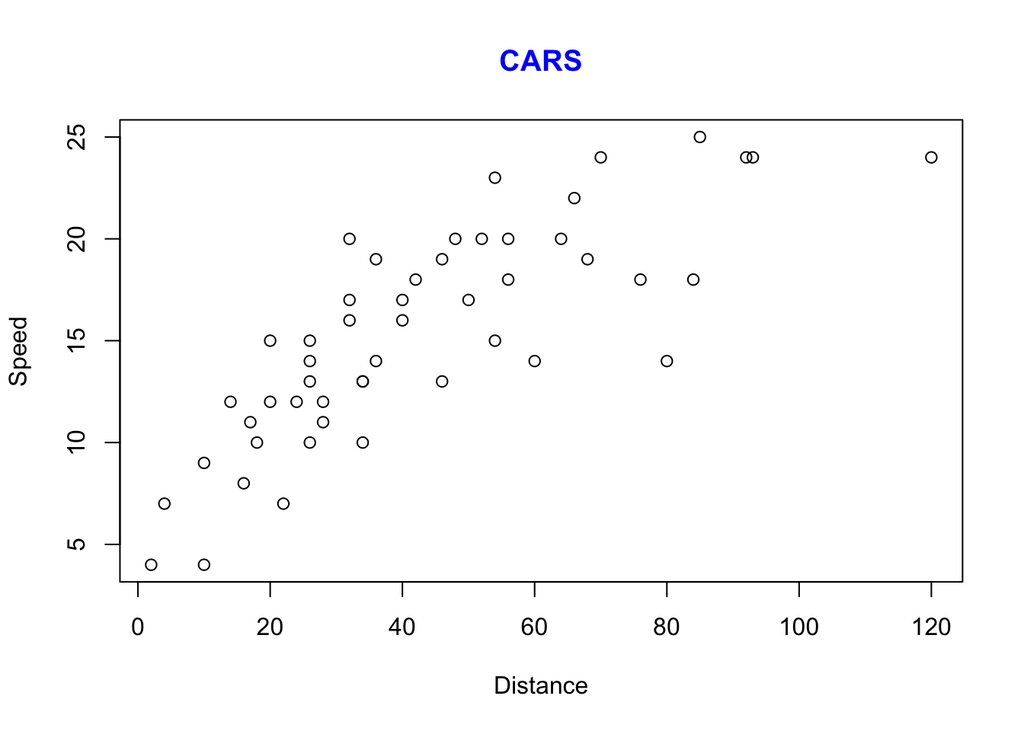

```r
plot(cars$dist, cars$speed, main="CARS", col.main = "blue", xlab="Distance", ylab="Speed")
```

2.2 Make a histogram of the distance variable.

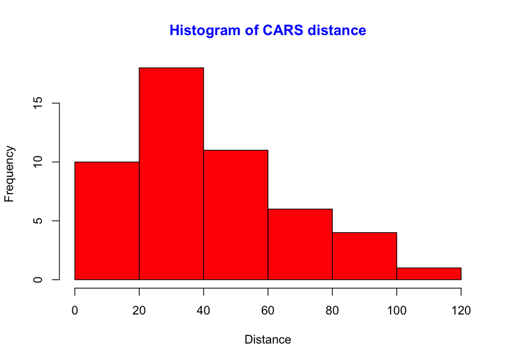

```r
hist(cars$dist, main="Histogram of CARS distance", col.main = "blue", xlab="Distance", col="red")
```

2.3 Make a histogram of the speed variable.

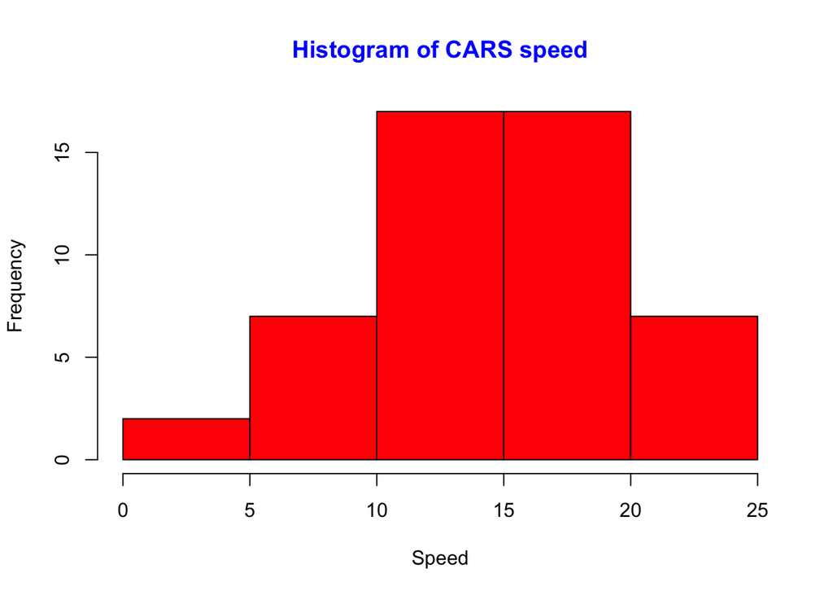

```r
hist(cars$speed, main="Histogram of CARS speed", col.main = "blue", xlab="Speed", col="red")
```

The modifications of section 2.4 have been made in the previous sections.